# Mini project on survival analysis

D.Khaleneva

3/8/2021

## EDA of ovarian dataset

Let’s look at the structure of the dataset:

```r
data(ovarian)
str(ovarian)
```

```
## 'data.frame':    26 obs. of  6 variables:
##  $ futime  : num  59 115 156 421 431 448 464 475 477 563 ...
##  $ fustat  : num  1 1 1 0 1 0 1 1 0 1 ...
##  $ age     : num  72.3 74.5 66.5 53.4 50.3 ...
##  $ resid.ds: num  2 2 2 2 2 1 2 2 2 1 ...
##  $ rx      : num  1 1 1 2 1 1 2 2 1 2 ...
##  $ ecog.ps : num  1 1 2 1 1 2 2 2 1 2 ...
```

Description of the data: Survival in a randomised trial comparing two treatments for ovarian cancer

- futime: survival or censoring time
- fustat: censoring status
- age: in years
- resid.ds: residual disease present (1=no,2=yes)
- rx: treatment group
- ecog.ps: ECOG performance status (1 is better than 2)

Check for NAs:

```r
sum(is.na(ovarian))
```

```
## [1] 0
```

No missing data in dataset

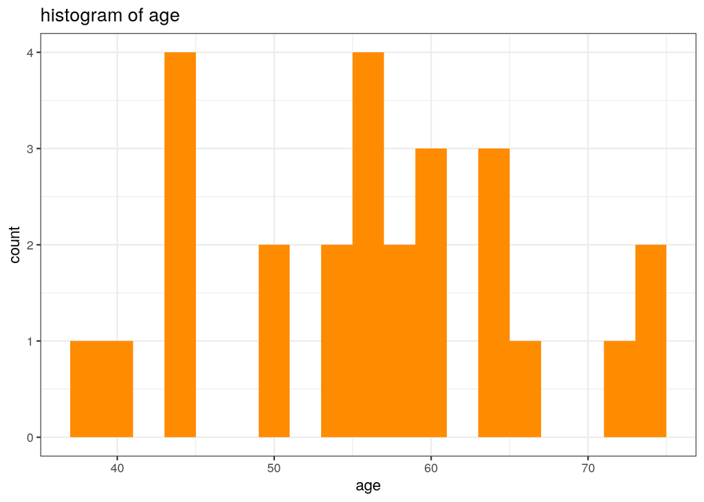

```r
ggplot(data=ovarian) + geom_histogram(aes(x=age),binwidth=2, bins = 10, fill='darkorange')+theme_bw()+labs(title = 'histogram of age')
```

The distribution of age is needed to make this parameter a factor with tho levels (young/old) in further analysis. Lets make the new data with fixed columns:

```r
ova <- mutate(ovarian, age_gr = ifelse((age < 55), "young", "old"),
              age_gr = factor(age_gr),
              ecog = factor(ecog.ps, labels=c("good","bad")),
              rx = factor(rx,labels=c("group 1","group 2")),
              resids = factor(resid.ds,labels=c("No","Yes")))
```

## Kaplan-Meier curves

Let us estimate the probability of death of a particular individual depending on the time t. To begin with, let’s get the time interval within which we will assess the survival rate.

```r
time_scale <- with(ova, Surv(futime, fustat))
head(time_scale,30)
```

```
##  [1]   59   115   156   421+  431   448+  464   475   477+  563   638   744+
## [13]  769+  770+  803+  855+ 1040+ 1106+ 1129+ 1206+ 1227+  268   329   353
## [25]  365   377+
```

```
## Call: survfit(formula = Surv(futime, fustat) ~ 1, data = ovarian)
##
##  time n.risk n.event survival std.err lower 95% CI upper 95% CI
##     1     26       0    1.000  0.0000        1.000        1.000
##    30     26       0    1.000  0.0000        1.000        1.000
##    60     25       1    0.962  0.0377        0.890        1.000
##    90     25       0    0.962  0.0377        0.890        1.000
##   180     23       2    0.885  0.0627        0.770        1.000
##   270     22       1    0.846  0.0708        0.718        0.997
##   360     20       2    0.769  0.0826        0.623        0.949
##   450     15       2    0.688  0.0919        0.529        0.894
##   540     12       2    0.596  0.0999        0.429        0.828
##   630     11       1    0.546  0.1032        0.377        0.791
##   720     10       1    0.497  0.1051        0.328        0.752
##   810      6       0    0.497  0.1051        0.328        0.752
##   900      5       0    0.497  0.1051        0.328        0.752
```

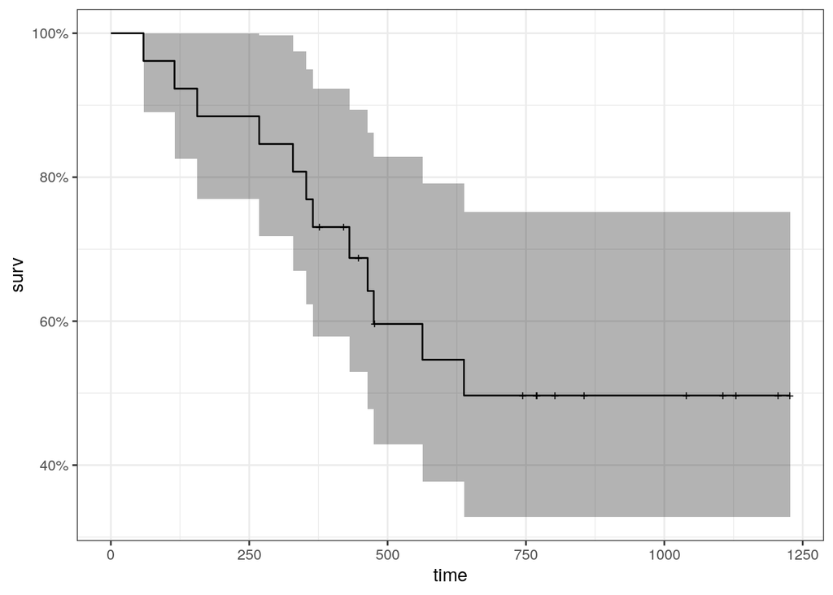

## Making groups

I made the following groups:

- Treatment curve
- Age curve
- Ecog curve
- Resid curve
- Curve for multiple factors

### Treatment curve

Stratification the curve depending on the treatment regimen rx that patients were assigned to.

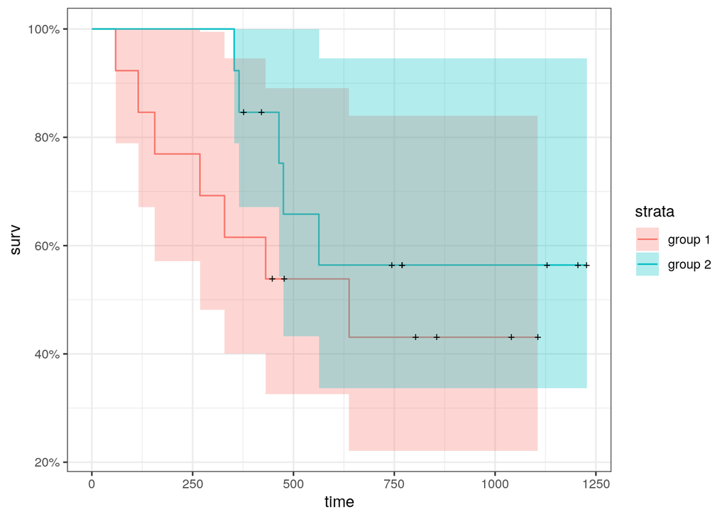

```r
surv_object <- Surv(time = ovarian$futime, event = ovarian$fustat)

surviver_rx <- survfit(surv_object ~ rx, data=ova)
autoplot(surviver_rx, title = "Treatment curve")+theme_bw()
```

### Age curve

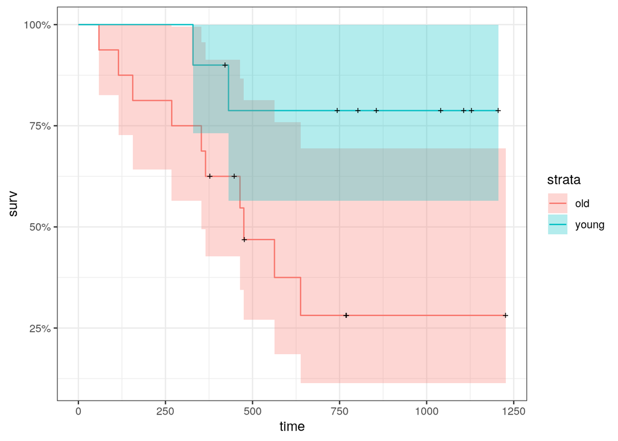

```r
age_surv <- survfit(surv_object ~ age_gr, data=ova)
autoplot(age_surv)+theme_bw()
```

### Ecog curve

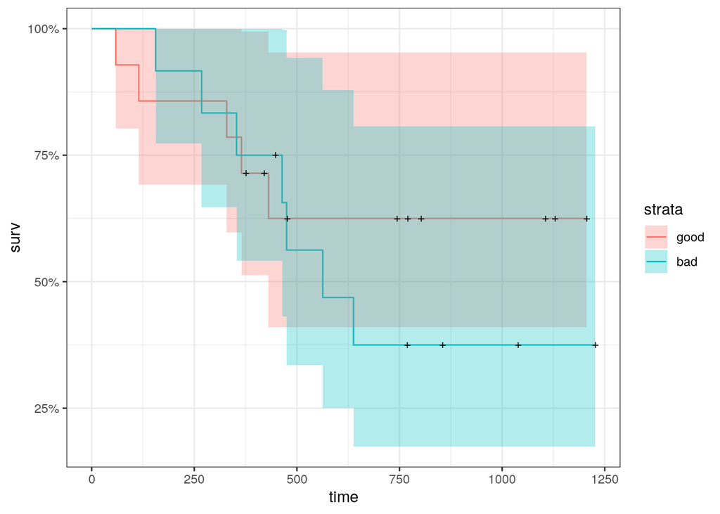

```r
age_surv <- survfit(surv_object ~ ecog, data=ova)
autoplot(age_surv)+theme_bw()
```

### Resid curve

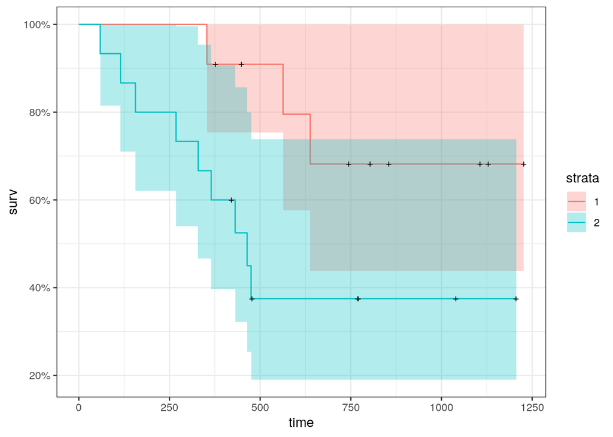

```r
resid_surv <- survfit(surv_object ~ resid.ds, data = ova)
autoplot(resid_surv) +theme_bw()
```

### Curve for all groups

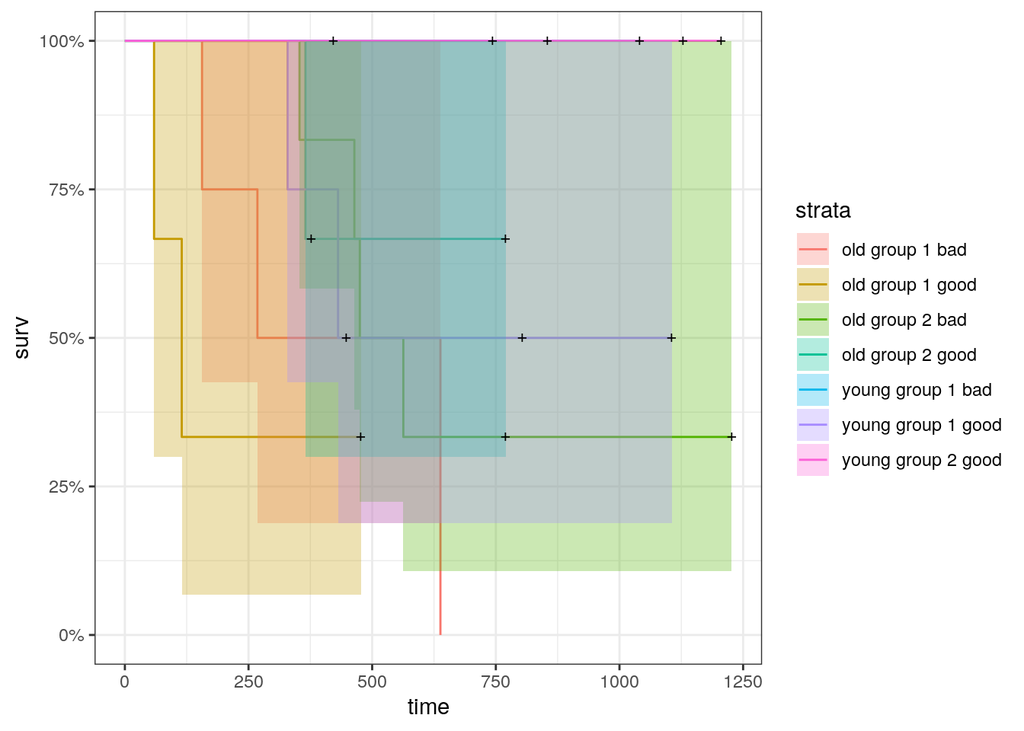

Here we see that age group affects on the survival pattern, but on this plot we cannot properly distinguish all groups. We should prepare another analysis to compare them

## Comparing groups with log-rank test

log-rank test is another way to assess survival. It allows you to compare whether there is a difference in survival between groups.

```r
logrank_test(surv_object ~ rx, data = ova_mix)
```

```
##
##  Asymptotic Two-Sample Logrank Test
##
## data:  surv_object by rx (group 1, group 2)
## Z = -1.0296, p-value = 0.3032
## alternative hypothesis: true theta is not equal to 1
```

```r
logrank_test(surv_object ~ ecog, data = ova_mix)
```

```
##
##  Asymptotic Two-Sample Logrank Test
##
## data:  surv_object by ecog (good, bad)
## Z = 0.69106, p-value = 0.4895
## alternative hypothesis: true theta is not equal to 1
```

```
##
##  Asymptotic Two-Sample Logrank Test
##
## data:  surv_object by age_gr (old, young)
## Z = -2.1721, p-value = 0.02985
## alternative hypothesis: true theta is not equal to 1
```

```
##
##  Asymptotic Two-Sample Logrank Test
##
## data:  surv_object by resids (No, Yes)
## Z = 1.9234, p-value = 0.05444
## alternative hypothesis: true theta is not equal to 1
```

## Analysis of factors influencing risk (Cox model)

```r
cox <- coxph(surv_object ~ age_gr+rx+resids , data = ova)
summary(cox)
```

```
## Call:
## coxph(formula = surv_object ~ age_gr + rx + resids, data = ova)
##
##   n= 26, number of events= 12
##
##                coef exp(coef) se(coef)      z Pr(>|z|)
## age_gryoung -1.7696    0.1704   0.8097 -2.186   0.0288 *
## rxgroup 2   -1.2411    0.2891   0.6284 -1.975   0.0483 *
## residsYes    1.2542    3.5050   0.6937  1.808   0.0706 .
## ---
## Signif. codes:  0 '***' 0.001 '**' 0.01 '*' 0.05 '.' 0.1 ' ' 1
##
##             exp(coef) exp(-coef) lower .95 upper .95
## age_gryoung    0.1704     5.8687   0.03486    0.8330
## rxgroup 2      0.2891     3.4594   0.08436    0.9905
## residsYes      3.5050     0.2853   0.90000   13.6497
##
## Concordance= 0.784  (se = 0.07 )
## Likelihood ratio test= 11.68  on 3 df,   p=0.009
## Wald test            = 9.47  on 3 df,   p=0.02
## Score (logrank) test = 10.6  on 3 df,   p=0.01
```

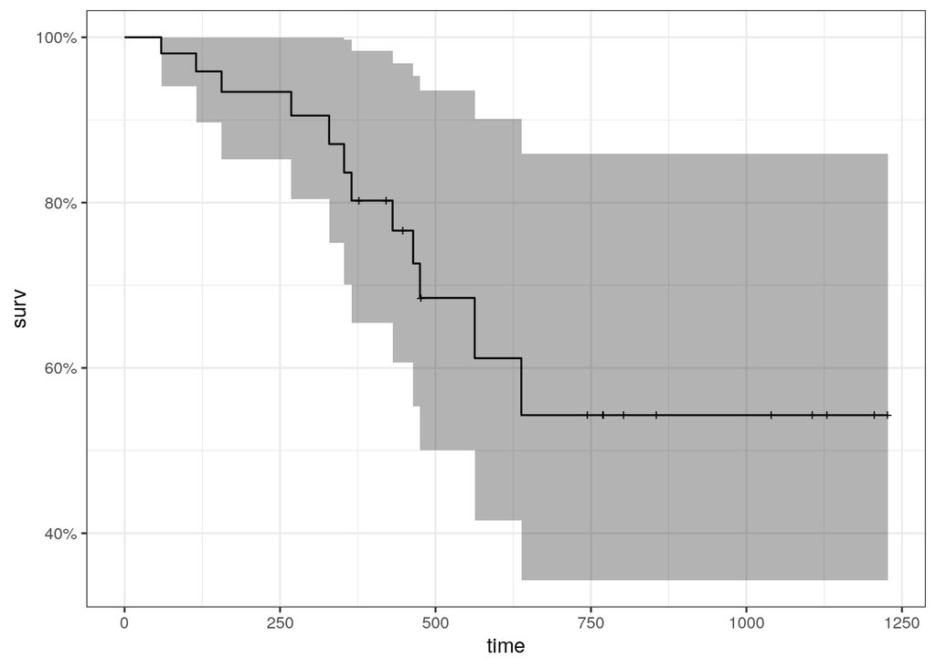

```r
cox_fit <- survfit(cox)
autoplot(cox_fit)+theme_bw()
```

The cox model does not reflect the relationship of variables and therefore is not very reliable for any conclusions, and the analysis of covariatesis needed:

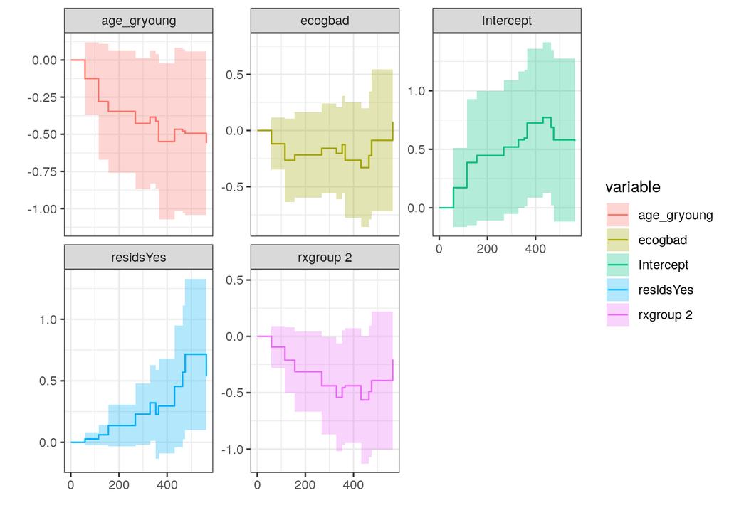

This analysis is needed to find the relationship between variables, as well as to see how variables change over time. If a variable changes much, we can`t be sure to trust the results in the analysis.

## Cox proportional hazards

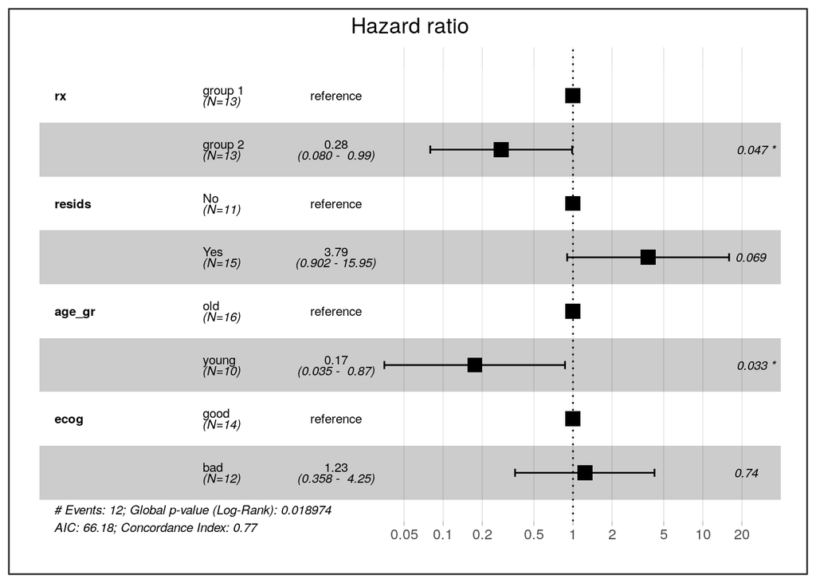

```r
# Fit a Cox proportional hazards model

fit.coxph <- coxph(surv_object ~ rx + resids + age_gr + ecog,
                   data = ova)
ggforest(fit.coxph, data = ova)+theme_bw()
```

Coxph plot shows hazard ratios (HR) which are derived from the model for all covariates that we included in the formula in coxph. HR > 1 indicates an increased risk of death (according to the definition of h(t)) if a specific condition is met by a patient. An HR < 1, on the other hand, indicates a decreased risk. p-value below indicates the level of significance of the criteria.

## References

Edmunson, J.H., Fleming, T.R., Decker, D.G., Malkasian, G.D., Jefferies, J.A., Webb, M.J., and Kvols, L.K., Different Chemotherapeutic Sensitivities and Host Factors Affecting Prognosis in Advanced Ovarian Carcinoma vs. Minimal Residual Disease. Cancer Treatment Reports, 63:241-47, 1979.